# 1. Data Understanding & Exploration:

```python
result= {}
result['XGBoost_Base model'] = fit_n_print(model, X_train, X_test, y_train ,y_test)
printResult(result)
```

| Model | Training accuracy | Tesing accuracy | auc | precision | recall | accuracy_cv | precision_cv | recall_cv | f1_cv | Elapsed |
| --- | --- | --- | --- | --- | --- | --- | --- | --- | --- | --- |
| Base model | 0.833866 | 0.807665 | 0.70942 | 0.690037 | 0.5 | 0.782038 | 0.604507 | 0.518393 | 0.558035 | 1.295858 |

### XGBoost model is giving 80% accuracy and 70% AUC score. Recall value is very less because of imbalance dataset.

### Just take a random model and return from the workflow method. Now in the below steps , i will be using different model and hypertune it to get the final model

### Here 1 means Churn yes and No mean churn No.

### False prediction is high .FP and FN is high

### 3. Various base models should be trained to select the best performing model.

#### Prepare different models with original Dataset and check the accuracy ,AUC and other parameter

```python
lc = LogisticRegression(random_state=1)
svc = SVC(random_state=1)
dt = DecisionTreeClassifier(random_state=1)
bc = BaggingClassifier(random_state=1)
rf = RandomForestClassifier(random_state=1, n_estimators=100)  # specifying n_estimators to avoid "future warnings"
gb = GradientBoostingClassifier(random_state=1, n_estimators=100)
xgBoost = xgb.XGBClassifier(random_state=1)
catBoostClfr =  CatBoostClassifier(random_state=1)
lbmclfr = LGBMClassifier(random_state=1)
knn = KNeighborsClassifier()
def calculateAccuracy(X_train, X_test,y_train, y_test):
    result={}
    for model, name  in zip([lc, svc, dt, bc, rf, gb, xgBoost, catBoostClfr, lbmclfr, knn], ['Logistic Classifier','SVM Classifier', 'Decision Tree',
                                                         'Bagging Ensemble', 'Random Forest', 'Gradient Boost Ensemble', 'XGBoost', 'CatBoostClassifier', 'LGBMClassifier', 'KNNClassifier']):
        result[name] = fit_n_print(model,X_train, X_test,y_train, y_test)
    return result
```

[output not shown]

[output cut: 946 more lines]

[output not shown]

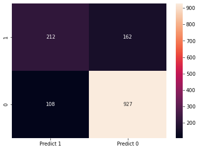

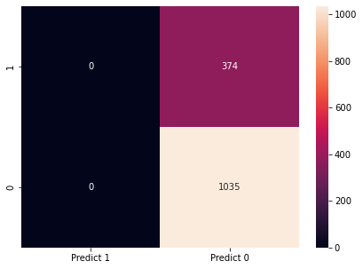

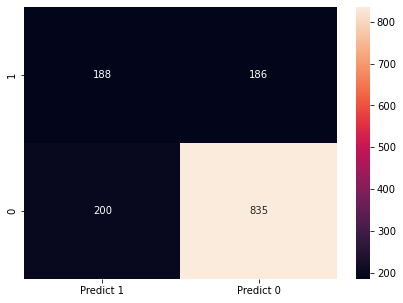

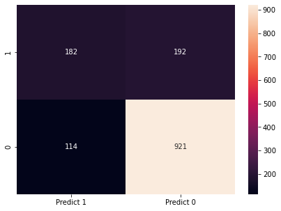

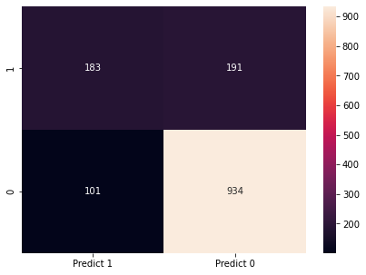

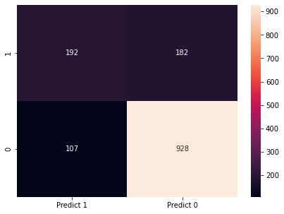

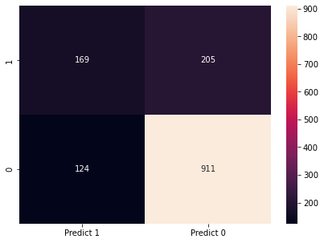

```python
result_org = calculateAccuracy(X_train, X_test,y_train, y_test)
```

```python
printResult(result_org)
```

| Model | Training accuracy | Tesing accuracy | auc | precision | recall | accuracy_cv | precision_cv | recall_cv | f1_cv | Elapsed |
| --- | --- | --- | --- | --- | --- | --- | --- | --- | --- | --- |
| Logistic Classifier | 0.801384 | 0.808375 | 0.731249 | 0.6625 | 0.566845 | 0.802094 | 0.647846 | 0.557187 | 0.598724 | 0.427223 |
| SVM Classifier | 0.734647 | 0.734564 | 0.5 | 0.0 | 0.0 | 0.734647 | 0.0 | 0.0 | 0.0 | 9.100948 |
| Decision Tree | 0.99787 | 0.726047 | 0.654719 | 0.484536 | 0.502674 | 0.730387 | 0.492579 | 0.50835 | 0.500236 | 0.329381 |
| Bagging Ensemble | 0.981541 | 0.782825 | 0.688243 | 0.614865 | 0.486631 | 0.775115 | 0.60156 | 0.454187 | 0.517394 | 0.843799 |
| Random Forest | 0.99787 | 0.792761 | 0.69586 | 0.644366 | 0.489305 | 0.790912 | 0.635879 | 0.496998 | 0.557899 | 2.857611 |
| Gradient Boost Ensemble | 0.827831 | 0.803407 | 0.709083 | 0.671378 | 0.508021 | 0.799432 | 0.654436 | 0.517078 | 0.577424 | 2.817808 |
| XGBoost | 0.833866 | 0.807665 | 0.70942 | 0.690037 | 0.5 | 0.782038 | 0.604507 | 0.518393 | 0.558035 | 1.285838 |
| CatBoostClassifier | 0.870962 | 0.797729 | 0.700949 | 0.658363 | 0.494652 | 0.797657 | 0.646541 | 0.523757 | 0.578659 | 11.351699 |
| LGBMClassifier | 0.881079 | 0.79489 | 0.704994 | 0.64214 | 0.513369 | 0.792865 | 0.628448 | 0.536471 | 0.578733 | 2.476666 |
| KNNClassifier | 0.829428 | 0.766501 | 0.666032 | 0.576792 | 0.451872 | 0.757721 | 0.555976 | 0.432779 | 0.486587 | 2.770066 |

### Various Models sare created with original dataset and check the accuracy and AUC scor. Since the dataset is imbalance , AUC score will be the best to predict the accuracy

### Compare the score with Normalized dataset and standardize dataset . Even After apply smote check the accuracy and AUC score.

### Here AUC score of Logistic classifier is giving highest score

### Graident Boost . XGBoost, CatBoostClassifer , LGBMClassifier is giving similar AUC score.

### CatBoostClassifier is taking much longer time to train.

#### Prepare models with Normalized Dataset and check the accuracy ,AUC and other parameter

[output not shown]

[output cut: 946 more lines]

[output not shown]

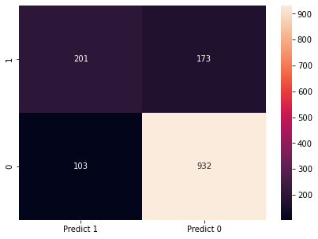

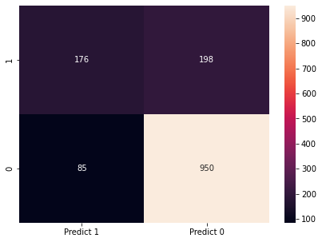

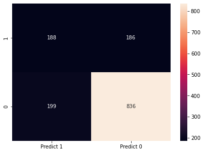

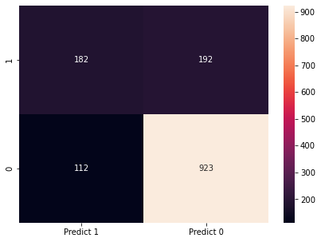

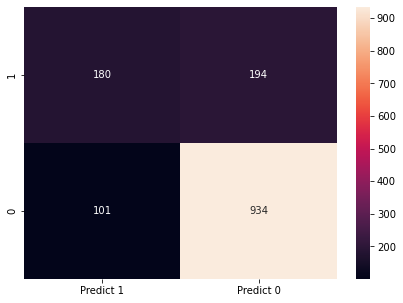

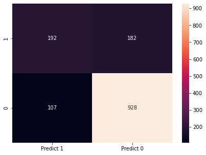

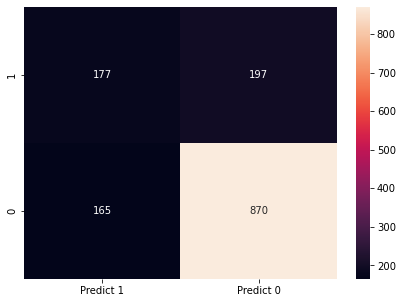

```python
result_norm=calculateAccuracy(X_train_norm, X_test_norm,y_train, y_test)
```

```python
printResult(result_norm)
```

| Model | Training accuracy | Tesing accuracy | auc | precision | recall | accuracy_cv | precision_cv | recall_cv | f1_cv | Elapsed |
| --- | --- | --- | --- | --- | --- | --- | --- | --- | --- | --- |
| Logistic Classifier | 0.805822 | 0.804116 | 0.718958 | 0.661184 | 0.537433 | 0.803869 | 0.656434 | 0.547832 | 0.597166 | 0.3465 |
| SVM Classifier | 0.812389 | 0.799148 | 0.694231 | 0.67433 | 0.470588 | 0.79748 | 0.659438 | 0.489638 | 0.561986 | 8.683061 |
| Decision Tree | 0.99787 | 0.726757 | 0.655202 | 0.485788 | 0.502674 | 0.731807 | 0.495176 | 0.509691 | 0.502257 | 0.263658 |
| Bagging Ensemble | 0.981363 | 0.784244 | 0.689209 | 0.619048 | 0.486631 | 0.77547 | 0.60271 | 0.454185 | 0.517727 | 0.8018 |
| Random Forest | 0.99787 | 0.790632 | 0.691849 | 0.640569 | 0.481283 | 0.789847 | 0.632944 | 0.495662 | 0.555946 | 2.385475 |
| Gradient Boost Ensemble | 0.827831 | 0.803407 | 0.709083 | 0.671378 | 0.508021 | 0.79961 | 0.655015 | 0.517078 | 0.577636 | 2.888336 |
| XGBoost | 0.833866 | 0.807665 | 0.70942 | 0.690037 | 0.5 | 0.782038 | 0.604483 | 0.518393 | 0.558032 | 1.28362 |
| CatBoostClassifier | 0.870962 | 0.797729 | 0.700949 | 0.658363 | 0.494652 | 0.797657 | 0.646541 | 0.523757 | 0.578659 | 11.202073 |
| LGBMClassifier | 0.881079 | 0.79489 | 0.704994 | 0.64214 | 0.513369 | 0.792865 | 0.628448 | 0.536471 | 0.578733 | 2.363236 |
| KNNClassifier | 0.834576 | 0.74308 | 0.656921 | 0.517544 | 0.473262 | 0.764643 | 0.558077 | 0.541815 | 0.549669 | 2.449249 |

### Normalized dataset is used to train different models.

### No hypertuning is performed on the dataset.

### AUC Score Logistics classifier , Graident Booster ,CatBoostClassifier, XGBoost and LGBMCLassifer is approx to 70%

### CatBoostClassifier is giving 79% Accuracy and 70% AUC score but it is taking longer time compared to other models

### SVM Classifier is having 80% accuracy and 70% AUC score, it is better than CatBoostClassifer as it is taking less time compared to CatBoostClassifier

#### Prepare models with Standardized Dataset and check the accuracy ,AUC and other parameter

[output not shown]

[output cut: 946 more lines]

[output not shown]

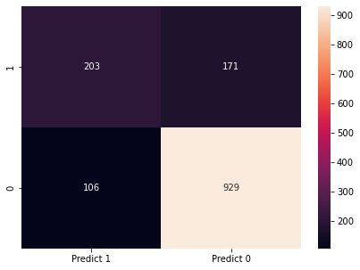

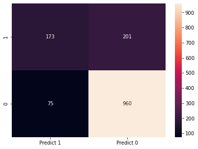

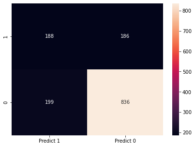

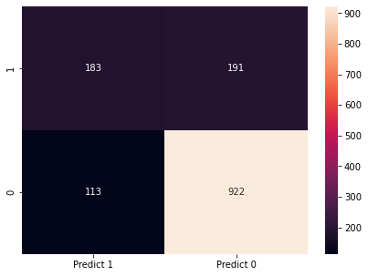

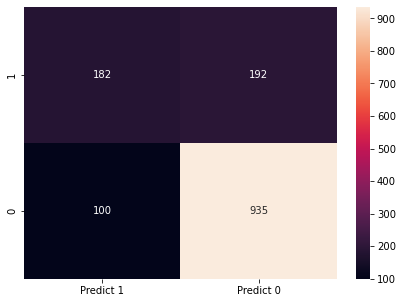

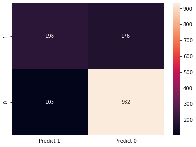

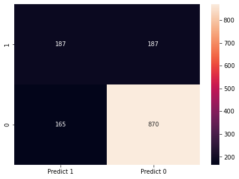

```python
result_std=calculateAccuracy(X_train_std, X_test_std,y_train, y_test)
```

```python
printResult(result_std)
```

| Model | Training accuracy | Tesing accuracy | auc | precision | recall | accuracy_cv | precision_cv | recall_cv | f1_cv | Elapsed |
| --- | --- | --- | --- | --- | --- | --- | --- | --- | --- | --- |
| Logistic Classifier | 0.804579 | 0.803407 | 0.720183 | 0.656958 | 0.542781 | 0.802272 | 0.649927 | 0.552515 | 0.597231 | 0.279736 |
| SVM Classifier | 0.811147 | 0.804116 | 0.695052 | 0.697581 | 0.462567 | 0.799432 | 0.673662 | 0.473582 | 0.556121 | 7.904451 |
| Decision Tree | 0.99787 | 0.726757 | 0.655202 | 0.485788 | 0.502674 | 0.730919 | 0.49353 | 0.508349 | 0.500706 | 0.252143 |
| Bagging Ensemble | 0.981186 | 0.784244 | 0.690063 | 0.618243 | 0.489305 | 0.77547 | 0.602664 | 0.454855 | 0.518152 | 0.77257 |
| Random Forest | 0.99787 | 0.792761 | 0.695006 | 0.64539 | 0.486631 | 0.79109 | 0.636544 | 0.49633 | 0.557749 | 2.516549 |
| Gradient Boost Ensemble | 0.827831 | 0.803407 | 0.709083 | 0.671378 | 0.508021 | 0.79961 | 0.655003 | 0.517078 | 0.577643 | 2.798898 |
| XGBoost | 0.833866 | 0.807665 | 0.70942 | 0.690037 | 0.5 | 0.781683 | 0.603699 | 0.517724 | 0.557307 | 1.288134 |
| CatBoostClassifier | 0.870962 | 0.797729 | 0.700949 | 0.658363 | 0.494652 | 0.797657 | 0.646541 | 0.523757 | 0.578659 | 10.216365 |
| LGBMClassifier | 0.883387 | 0.801987 | 0.714947 | 0.657807 | 0.529412 | 0.790557 | 0.621573 | 0.539136 | 0.577412 | 2.183613 |
| KNNClassifier | 0.838658 | 0.750177 | 0.67029 | 0.53125 | 0.5 | 0.772098 | 0.575255 | 0.539802 | 0.556909 | 2.507213 |

### Accuracy and AUC score of different models on Standarized dataset is almost same as with Normalized dataset

### There is very minor difference in decimals between Standardzied and Normalized dataset on different models

#### Balance the imbalance dataset using SMOTE

```python
from imblearn.over_sampling import SMOTE
sm = SMOTE(random_state = 2)
X_train_balance, y_train_balance = sm.fit_resample(X_train_norm, y_train)
```

#### Prepare models with Normalized BALANCED Dataset and check the accuracy ,AUC and other parameter

[output not shown]

[output cut: 946 more lines]

[output not shown]

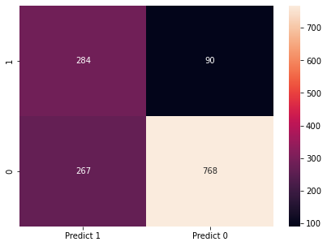

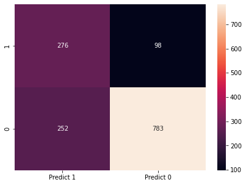

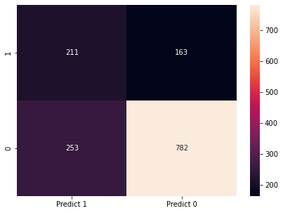

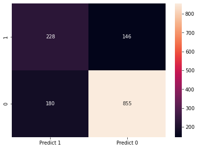

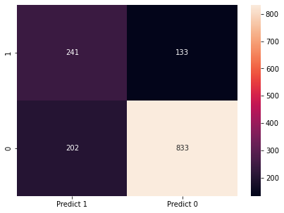

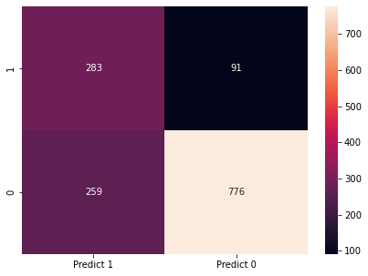

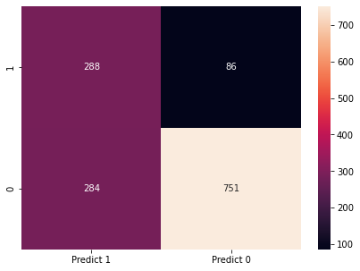

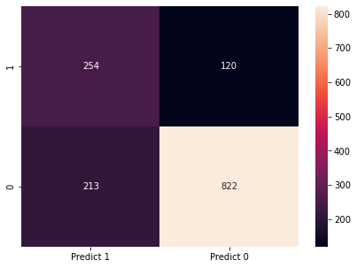

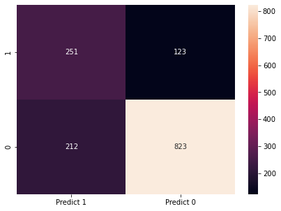

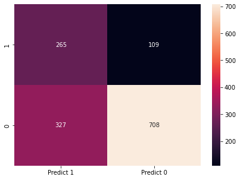

```python
result_balance=calculateAccuracy(X_train_balance, X_test_norm,y_train_balance, y_test)
```

```python
printResult(result_balance)
```

| Model | Training accuracy | Tesing accuracy | auc | precision | recall | accuracy_cv | precision_cv | recall_cv | f1_cv | Elapsed |
| --- | --- | --- | --- | --- | --- | --- | --- | --- | --- | --- |
| Logistic Classifier | 0.788959 | 0.746629 | 0.750694 | 0.515426 | 0.759358 | 0.78413 | 0.765194 | 0.819286 | 0.790682 | 0.518102 |
| SVM Classifier | 0.808891 | 0.751597 | 0.747245 | 0.522727 | 0.737968 | 0.783648 | 0.764003 | 0.819771 | 0.790332 | 17.238115 |
| Decision Tree | 0.99855 | 0.704755 | 0.659863 | 0.454741 | 0.564171 | 0.759729 | 0.756652 | 0.765414 | 0.75948 | 0.307184 |
| Bagging Ensemble | 0.988645 | 0.76863 | 0.717856 | 0.558824 | 0.609626 | 0.802735 | 0.804426 | 0.799728 | 0.799963 | 1.107735 |
| Random Forest | 0.99855 | 0.762243 | 0.724608 | 0.544018 | 0.644385 | 0.831366 | 0.810047 | 0.864717 | 0.835132 | 3.522776 |
| Gradient Boost Ensemble | 0.823266 | 0.751597 | 0.753221 | 0.52214 | 0.756684 | 0.796454 | 0.772801 | 0.838378 | 0.803372 | 4.032368 |
| XGBoost | 0.818555 | 0.737402 | 0.747829 | 0.503497 | 0.770053 | 0.803828 | 0.802243 | 0.805054 | 0.796142 | 1.569669 |
| CatBoostClassifier | 0.894177 | 0.763662 | 0.736674 | 0.543897 | 0.679144 | 0.812523 | 0.799928 | 0.831864 | 0.811726 | 14.305119 |
| LGBMClassifier | 0.893211 | 0.762243 | 0.733146 | 0.542117 | 0.671123 | 0.812765 | 0.800177 | 0.831865 | 0.812034 | 1.945941 |
| KNNClassifier | 0.857453 | 0.690561 | 0.696307 | 0.447635 | 0.708556 | 0.798626 | 0.743505 | 0.911339 | 0.818798 | 4.354356 |

### No change in Decision Tree AUC Score

### AUC score of Bagging Ensemble has been increased from 0.690063 to 0.717856

### AUC score of Random Forest has been increased from 0.695006 to 0.724608

### AUC score of Gradient Boost Ensemble has been increased from 0.709083 to 0.753221

### AUC score of XGBoost has been increased from 0.70942 to 0.747829

### AUC score of CatBoostClassifier has been increased from 0.700949 to 0.736674

### AUC score of LGBMClassifier has been increased from 0.714947 to 0.733146

### No Change In kNN classifer AUC Score

### From these model Accuracy and AUC score is highest for GradientBoost Ensemble model

### Now perform the Hypertuning and see which one is giving maximum Accuracy and AUC score

#### Display Confusion matrix for all the models

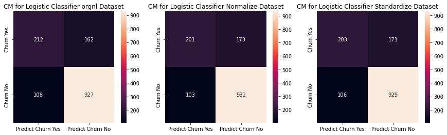

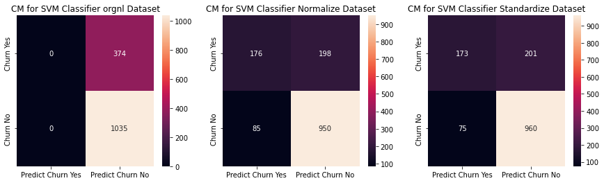

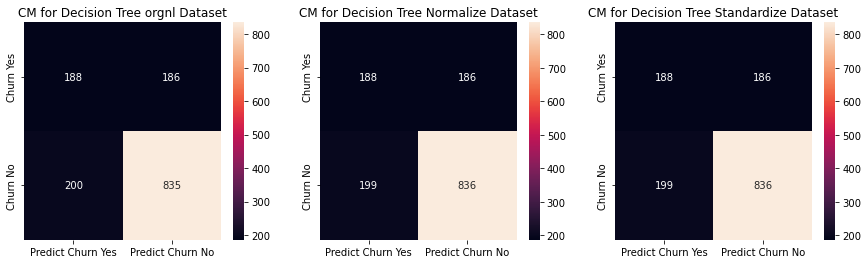

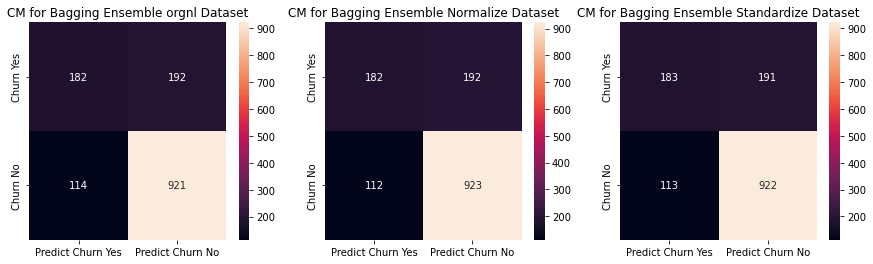

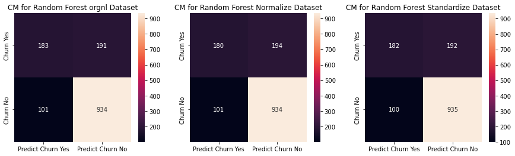

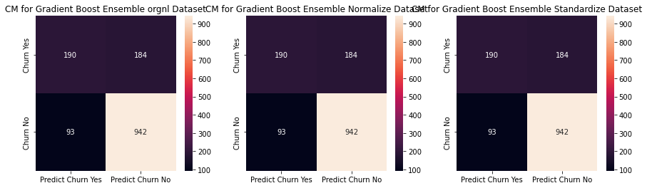

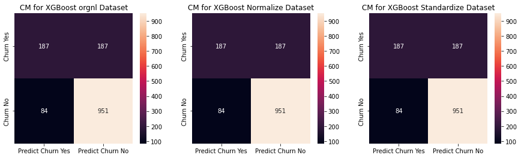

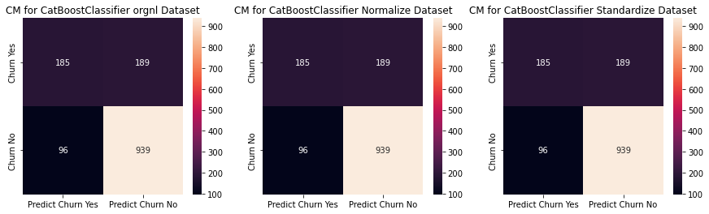

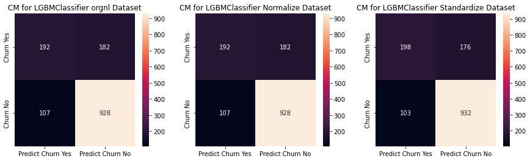

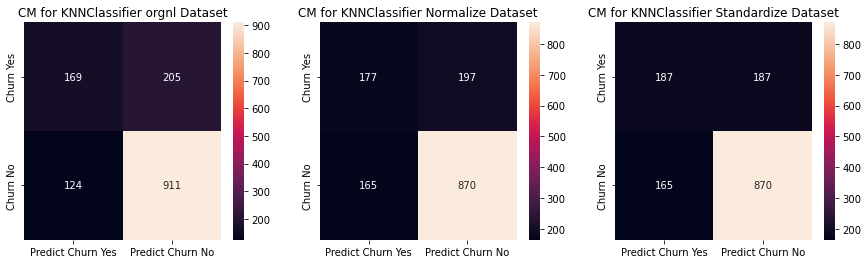

```python
for model in ['Logistic Classifier','SVM Classifier', 'Decision Tree',
                                                     'Bagging Ensemble', 'Random Forest', 'Gradient Boost Ensemble', 'XGBoost', 'CatBoostClassifier', 'LGBMClassifier', 'KNNClassifier']:
    compareConfusionMatrix(model, y_test, result_org[model][10], result_norm[model][10], result_std[model][10], labels=[1,0])
```

### Prepare the hypertuning parameters for some of the models.

### Since Hypertuning is taking lot of time, we have used the CV value to 3.

```python
params = {
    'Logistic Classifier':{
         'C' :  np.logspace(-5, 8, 15),
        'penalty': ['l1', 'l2'],
        "solver": ['lbfgs','liblinear']
    },
    'SVM Classifier':{
        'C': [0.1, 1, 10],
        'gamma': [1.5,1, 0.1],
        'kernel': ['rbf']
    },
    'Decision Tree':{
    'max_depth': [2,9,10,15],
    'min_samples_leaf': [5,25,30,35],
    'criterion': ["entropy"],
    'max_leaf_nodes':[55, 60,65,70,]
    },
    'Random Forest':{
        'max_depth': [12, 15,20],
        'max_features': [1,2],
        'min_samples_leaf': [ 1,2],
        'n_estimators': [250,300]
    },
    'Gradient Boost Ensemble':{
        "n_estimators":[250,300,320],
        "max_depth":[5,7 ,8],
        "learning_rate":[0.1,0.2, 0.4]
    },
    'XGBoost':{
        "colsample_bytree": uniform(0.9, 0.3),
        "gamma": uniform(0.2, 0.5),
        "learning_rate": uniform(0.01, 0.2), # default 0.1
        "max_depth": randint(2, 5), # default 3
        "n_estimators": randint(100, 200), # default 100
        "subsample": uniform(0.8, 0.4)
    },
    'LGBMClassifier':{
        'learning_rate': [0.001, 0.1,0.3,0.5 ],
        'num_leaves': [40,90,100,120,125],
        'feature_fraction': [0.3,0.4,0.45],
        'bagging_fraction': [0.01,0.1,0.2,0.4,0.5],
        'max_depth': [15,20,25,30],
        'max_bin':[100, 120,140],
        'min_data_in_leaf': [5,10,15]
    },
    'KNNClassifier':{
        'n_neighbors' : list(np.arange(3,30,2)),
        'p' :[1,2],
        'weights' : ['uniform','distance']
    }
}
```

```
-------------------------------------------------------------
Hypertuning is performing for model start Logistic Classifier
-------------------------------------------------------------
Fitting 3 folds for each of 60 candidates, totalling 180 fits
Model with rank: 1
Mean validation score: 0.864 (std: 0.026)
Parameters: {'solver': 'liblinear', 'penalty': 'l2', 'C': 2275.845926074791}

LogisticRegression(C=2275.845926074791, random_state=1, solver='liblinear')
-------------------------------------------------------------
Hypertuning is performing for model end Logistic Classifier
-------------------------------------------------------------
-------------------------------------------------------------
Hypertuning is performing for model start SVM Classifier
-------------------------------------------------------------
Fitting 3 folds for each of 9 candidates, totalling 27 fits
Model with rank: 1
Mean validation score: 0.896 (std: 0.034)
Parameters: {'kernel': 'rbf', 'gamma': 1, 'C': 1}

SVC(C=1, gamma=1, random_state=1)
-------------------------------------------------------------
Hypertuning is performing for model end SVM Classifier
-------------------------------------------------------------
-------------------------------------------------------------
Hypertuning is performing for model start Decision Tree
-------------------------------------------------------------
Fitting 3 folds for each of 64 candidates, totalling 192 fits
Model with rank: 1
Mean validation score: 0.855 (std: 0.020)
Parameters: {'min_samples_leaf': 30, 'max_leaf_nodes': 60, 'max_depth': 10, 'criterion': 'entropy'}

DecisionTreeClassifier(criterion='entropy', max_depth=10, max_leaf_nodes=60,
                       min_samples_leaf=30, random_state=1)
-------------------------------------------------------------
Hypertuning is performing for model end Decision Tree
-------------------------------------------------------------
-------------------------------------------------------------
Hypertuning is performing for model start Random Forest
-------------------------------------------------------------
```

[output cut: 86 more lines]

```
-------------------------------------------------------------
Hypertuning is performing for model end LGBMClassifier
-------------------------------------------------------------
-------------------------------------------------------------
Hypertuning is performing for model start KNNClassifier
-------------------------------------------------------------
Fitting 3 folds for each of 56 candidates, totalling 168 fits
Model with rank: 1
Mean validation score: 0.893 (std: 0.022)
Parameters: {'weights': 'distance', 'p': 1, 'n_neighbors': 15}

KNeighborsClassifier(n_neighbors=15, p=1, weights='distance')
-------------------------------------------------------------
Hypertuning is performing for model end KNNClassifier
-------------------------------------------------------------
```

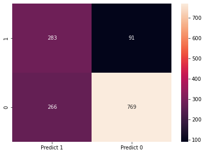

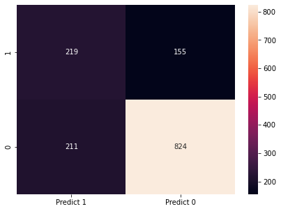

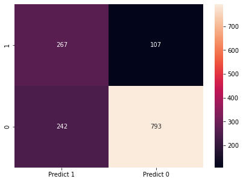

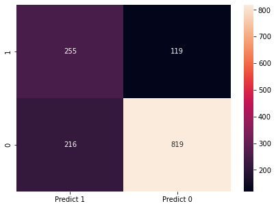

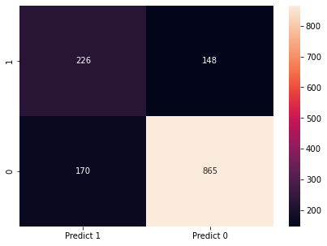

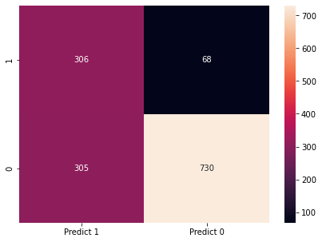

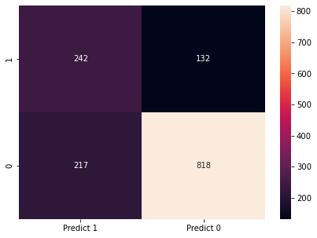

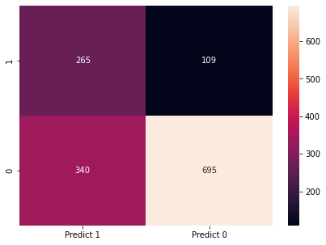

```python
result_hypertune= {}
for model, name  in zip([lc,svc, dt, rf, gb, xgBoost, lbmclfr, knn], ['Logistic Classifier','SVM Classifier', 'Decision Tree',
                                                      'Random Forest', 'Gradient Boost Ensemble', 'XGBoost', 'LGBMClassifier', 'KNNClassifier']):
    print('-------------------------------------------------------------')
    print('Hypertuning is performing for model start', name)
    print('-------------------------------------------------------------')
    model = report_randomiseSearchCV(model, params[name], X_train_balance, y_train_balance, X_test_norm, y_test)
    result_hypertune[name+'_Balance_DataSet'] = fit_n_print(model,X_train_balance, X_test_norm,y_train_balance , y_test)
    print('-------------------------------------------------------------')
    print('Hypertuning is performing for model end', name)
    print('-------------------------------------------------------------')
```

```python
printResult(result_hypertune)
```

| Model | Training accuracy | Tesing accuracy | auc | precision | recall | accuracy_cv | precision_cv | recall_cv | f1_cv | Elapsed |
| --- | --- | --- | --- | --- | --- | --- | --- | --- | --- | --- |
| Logistic Classifier_Balance_DataSet | 0.790529 | 0.746629 | 0.74984 | 0.515483 | 0.756684 | 0.783164 | 0.764494 | 0.817596 | 0.789576 | 0.313465 |
| SVM Classifier_Balance_DataSet | 0.921962 | 0.740241 | 0.690848 | 0.509302 | 0.585561 | 0.828226 | 0.814727 | 0.848285 | 0.829372 | 22.27106 |
| Decision Tree_Balance_DataSet | 0.802368 | 0.752307 | 0.740044 | 0.524558 | 0.713904 | 0.770843 | 0.752321 | 0.806961 | 0.778581 | 0.300882 |
| Random Forest_Balance_DataSet | 0.974028 | 0.762243 | 0.736561 | 0.541401 | 0.681818 | 0.839941 | 0.809644 | 0.888874 | 0.846477 | 6.840174 |
| Gradient Boost Ensemble_Balance_DataSet | 0.99855 | 0.774308 | 0.720013 | 0.570707 | 0.604278 | 0.809145 | 0.819823 | 0.792254 | 0.79461 | 29.015493 |
| XGBoost_Balance_DataSet | 0.79367 | 0.735273 | 0.761748 | 0.500818 | 0.818182 | 0.802737 | 0.784458 | 0.833068 | 0.806136 | 1.368771 |
| LGBMClassifier_Balance_DataSet | 0.93827 | 0.752307 | 0.718698 | 0.527233 | 0.647059 | 0.813369 | 0.804429 | 0.827032 | 0.81184 | 2.350673 |
| KNNClassifier_Balance_DataSet | 0.99855 | 0.681334 | 0.690027 | 0.438017 | 0.708556 | 0.801525 | 0.745606 | 0.914963 | 0.821506 | 8.238415 |

### XGBoost Classifier is giving 73% Accuracy , and highest AUC score . It is also giving 81% recall. The time taken to calculate the prediction is also good of XGBoost.

### Hence XGBoost is the best estimator for the problem

### 4. Pickle file should be saved for the best performing model.

#### saving the XGBoost classifier into the finalized_model.sav file.

```python
def writeModelToFile(model, fileName):
    '''
    writeModelToFile is used to save the model to File
    Param 1: Accept the model which need to be saved
    Param 2: Accept the file Name where the model has to be saved.
    '''
    pickle.dump(model, open(filename, 'wb'))
    print('Model saved successfully')
def loadModelFromFile(fileName):
    '''
    loadModelFromFile is used to read the model from File
    Param 1: Accept the file Name where the model has to be read.
    '''
    model = pickle.load(open(filename, 'rb'))
    return model;
```

#### Saving the mode into file

```python
filename = 'finalized_model.sav'
writeModelToFile(xgBoost, filename)
```

```
Model saved successfully
```

```python
#### Read The model from the file
```

```python
best_model = loadModelFromFile(filename);
result = best_model.score(X_test_norm, y_test)
print(result)
```

```
0.7374024130589071
```

### Using Pickle, Model is saved into the file and same model is used later on for prediction.